# Introduction to Biostatistical Computing PHC 6937

Overview

Zhiguang Huo (Caleb)

Monday August 24, 2022

# Basic description of this class

- Lecturer: Zhiguang Huo (Caleb) zhuo@ufl.edu
- TAs: None
- Deliver format:
  - On campus: Room: [HPNP G210](https://campusmap.ufl.edu/#/index/0212)
- Lecture times:
  - Monday: 12:50-2:45pm
  - Wednesday: 1:55-2:45pm
- Office hours
  - Caleb: Monday 3:00-4:30pm
- Course Website:

https://caleb-huo.github.io/teaching/2022FALL/biostatisticalComputing.html

- [elearning](http://elearning.ufl.edu/): used to collect submissions, and keep track of grades

# More description of this class

- Will learning programming languages in the context of data science
  - R
  - Python
- No prior programming knowledge assumed
- Some statistics knowledge is preferred
  - An introductory course in statistics that covers statistical inference, such as PHC6052 Introduction to Biostatistical Methods
- Class will be cumulative, so keep up with the material and assignments!

# Contents of this class

- Lecture notes https://caleb-huo.github.io/teaching/2022FALL/biostatisticalComputing.html
  - Former part: how to use R.
  - Later part: how to use Python.
- See syllabus https://caleb-huo.github.io/teaching/2022FALL/PHC6068_2022_Intro_Biostatistical_Computing_Syllabus.pdf
- Homework assignment, Exams, Final projects and grades will be available on [elearning](http://elearning.ufl.edu/)

# Textbook

- No textbook is required
- Recommanded reading:
  - R
    - Hadley Wickham (2014). Advanced R. Taylor & Francis. http://adv-r.had.co.nz
    - Garrett Grolemund and Hadley Wickham (2016). R for Data Science. O’Reilly Media, Inc., https://r4ds.had.co.nz/
  - Python
    - Wes McKinney (2012). Python for Data Analysis, [https://www.oreilly.com/library/view/python-for- data/9781449323592/](https://www.oreilly.com/library/view/python-for-%20data/9781449323592/)
    - Jake VanderPlas (2016). Python Data Science Handbook. https://jakevdp.github.io/PythonDataScienceHandbook/

# Assignment

grading (total 100%)

| Requirement | points |
| --- | --- |
| Homework1 | 5% |
| Homework2 | 5% |
| Mid-term exam | 25% |
| Homework3 | 5% |
| Homework4 | 5% |
| Homework5 | 5% |
| Final project | 25% |
| Final exam | 25% |

# Exams

- Mid-term exam:
  - Take-home exam (1 week) on R programming.
- Final exam:
  - Take-home exam (1 week) on Python programming.
- Format:
  - Will be released/submitted in R markdown/Jupyter.
- Due time:
  - See course website, **no late exam submissions**.
- Can I work with other people?
  - No, **you are not allowed to discuss with other people since this is exam**.

# Homework policy

- Format: will be released/submitted in markdown format.
  - R markdown for R programming.
  - Jupyter for Python programming.
- Due time:
  - Two weeks after the homework is released, usually due on Monday 11:59 pm.
- Late homework:
  - 80% credit within one day late;
  - 50% credit within two day late;
  - 0% after two day’s late.
- Grace period: totally 2 days.
  - Can be applied to any homework (not exam or final project).
  - Each time at least one day of grace period will be used.
- Where to submit: electronically via [elearning](http://elearning.ufl.edu/).
- Can I work with other people?
  - Yes. You are allowed to discuss how to do the Homework with your classmates.
  - No. But you have to write your own solution.

# Final project

- Wrap up a R package/R Shiny app
  - Complete documentation of all your functions.
  - Apply R package to real data or synthetic data.
  - Report using R markdown, include how to use the package.
  - Pass all warning and error checks.
- How to make an outstanding R package?
  - Calling c++
  - Make nice vignette
  - A comprehensive package
  - Host the package on GitHub
- Instructions: will be released on Monday Oct 3rd.
- Can work alone, or work in group with less than 3.

# Trouble shooting

# Other Policy

- Attendance
  - Attendance is encouraged but not required.
- Recorded lecture video
  - The lecture will be recorded via zoom.
  - The recorded videos are available upon reasonable request (sick)
  - Should only be used to review the lecture by yourself.
  - Should not be distributed for any other purpose

# Any question about administration?

# What software do we need?

- R is a programming language for statistical computing
  - R Studio is an integrated development environment (IDE) for R programming
  - R Markdown is a markup language for combining R code with text
- Python is widely used for data science and machine learning
  - Anaconda is an integrated development environment (IDE) for Python programming
  - Jupyter is a markup language for combining Python code with text

All of these are free

# Installing R

- R can be downloaded from the ``Comprehensive R Archive Network" (CRAN).
- R can be installed on Windows, Mac or Linux operating systems.
- In this course, the instructors will run R on Mac.
- To install R, visit the R website, http://www.r-project.org and follow the installation directions (see the FAQ section for more details).
- R version 4.0 and above are required for this class.

# R Console

- open R console

[figure not shown]

# RStudio

- RStudio is a free and open source integrated development environment (IDE) designed specifically for R. http://www.rstudio.com
- Runs on, Windows, Mac or Linux operating systems.
- Useful productivity tools：
  - Syntax highlighting, smart indention, parentheses matching
  - Easily execute code from the source editor
  - Integrates all of the tools (source editor, console, plots, documentation, and more) when working with R into a single environment
  - Extensive tools for developing R packages
  - Interactive debugging for diagnosing and fixing errors

[figure not shown]

# R markdown

- Will be introduced today if there are any remaining time
- Otherwise will be introduced next Monday

# Install Python

- Python can be installed on Windows, Mac or Linux operating systems.
- In this course, the instructors will run Python on Mac.
- To install Python, visit the Python website, https://www.python.org/downloads/release/python-3106/.
- Python version 3.8 and above are required for this class.

# Python Console

- open Python console via command line:
  - MAC user:
    - Open Terminal
    - just typing python, python3, python3.8, or python3.9
  - Windows user:
    - open the Start Menu via clicking the Start Button
    - Click Windows System, then select Command Prompt with the black icon.
    - just typing python, python3, python3.8, or python3.9

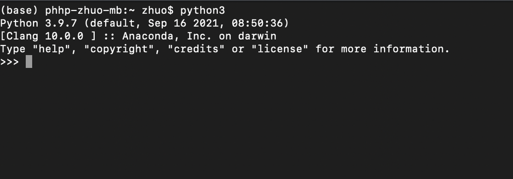

# Anaconda

- Anaconda is a free and open source integrated development environment (IDE) for python. https://www.anaconda.com
- Runs on, Windows, Mac or Linux operating systems.
- Useful productivity tools：
  - Integrate many popular data science tools including Jupyter, PyCharm
  - Allow creating user level environment independent of the operating system or admin libraries

[figure not shown]

# Comparison of R and Python

- Commonality:
  - both are open source languages, free to use for everyone
  - both are well suited for data science
    - data clearning
    - data manipulation
    - data visualization
- Difference:
  - R is rooted in statistical analysis.
  - Python is general-purpose programming language, more widely used in machine learning and deep learning

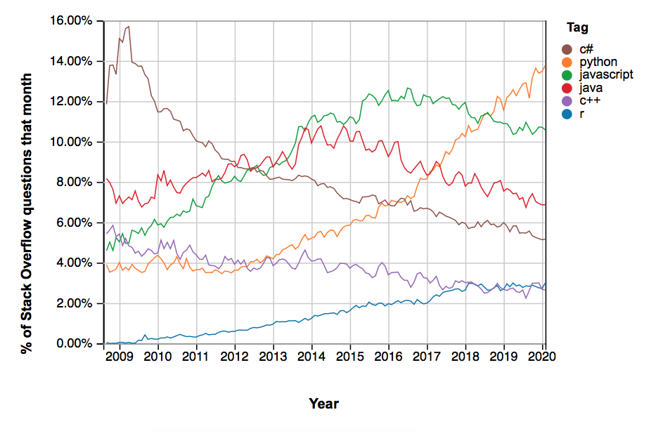

# Some drawbacks of R and Python

- R and Python are slow in loop (e.g. for, while), so try to avoid loops if you run a large program and care about speed.
  - Solution: vectorize your program.

# Things you should have done, by the end of this week

- Install R (>4.0) and R Studio on your laptop
- Install Python (>3.8) and Anaconda on your laptop

# HiPerGator

- HiPerGator is high performance computing for UF.
- High performance computing is widely used in both academy and industry
- Will be introduced in later lectures.
- *Acceptable Use Policy*:
  - ACCEPTABLE USE I acknowledge that the access to the HPC resources operated by UF Research Computing is subject to the UF Acceptable Use Policy at https://it.ufl.edu/policies/acceptable-use/acceptable-use-policy/ and the Research Computing policies at http://www.rc.ufl.edu/services/procedures/ and that I am responsible for following these policies.
  - RESTRICTED DATA I also certify that using restricted data and software on the HPC resources requires extra steps described at UFRC Policies and at UFRC Export Policies, and that I will notify both my account sponsor and the Office of Research (Research Compliance) and Research Computing at support.rc.ufl.edu when I am working with such data.